# Repro Research Proj 2

R Corn

June 29, 2017

## Health and Economic Ipmacts of Weather Events in the US

# Synopsis

This project involves exploring the US NOAA storm database to get an idea of what health and economic losses can be attributed to certain types of weather events.

# Data Processing

The data for this assignment come in the form of a comma-separated-value file compressed via the bzip2 algorithm to reduce its size. You can download the file from the course web site:

[Storm Data](https://d396qusza40orc.cloudfront.net/repdata%2Fdata%2FStormData.csv.bz2)

There is also some documentation of the database available. Here you will find how some of the variables are constructed/defined.

[National Weather Service Storm Data Documentation](https://d396qusza40orc.cloudfront.net/repdata%2Fpeer2_doc%2Fpd01016005curr.pdf)

[National Climatic Data Center Storm Events FAQ](https://d396qusza40orc.cloudfront.net/repdata%2Fpeer2_doc%2FNCDC%20Storm%20Events-FAQ%20Page.pdf)

Downloading data file to WD, unzipping, and reading it into a dataframe if not already done.

```r
url <- "https://d396qusza40orc.cloudfront.net/repdata%2Fdata%2FStormData.csv.bz2"

if (!file.exists("StormData.csv.bz2")) {

  download.file(url, "StormData.csv.bz2")
}

 if (!file.exists("StormData.csv")) {
   library(R.utils)
  bunzip2("StormData.csv.bz2", "StormData.csv")
}
df <- read.csv("StormData.csv", stringsAsFactors = FALSE)

library(dplyr)
```

Selecting the needed columns for comparing events to fatalities, summarizing by sum, and arranging in decreasing order Shown are the worst 6 event types with regards to fatalities

```r
fatal <- select(df, EVTYPE, FATALITIES)
fatal <- group_by(fatal, EVTYPE)
fatal <- summarize(fatal, totalfatal = sum(FATALITIES))
fatal <- arrange(fatal, -totalfatal)
head(fatal)
```

```
## # A tibble: 6 x 2
##           EVTYPE totalfatal
##            <chr>      <dbl>
## 1        TORNADO       5633
## 2 EXCESSIVE HEAT       1903
## 3    FLASH FLOOD        978
## 4           HEAT        937
## 5      LIGHTNING        816
## 6      TSTM WIND        504
```

Selecting the needed columns for comparing events to injuries, summarizing by sum, and arranging in decreasing order Shown are the worst 6 event types with regards to injuries

```r
injure <- select(df, EVTYPE, INJURIES)
injure <- group_by(injure, EVTYPE)
injure <- summarize(injure, totalinjure = sum(INJURIES))
injure <- arrange(injure, -totalinjure)
head(injure)
```

```
## # A tibble: 6 x 2
##           EVTYPE totalinjure
##            <chr>       <dbl>
## 1        TORNADO       91346
## 2      TSTM WIND        6957
## 3          FLOOD        6789
## 4 EXCESSIVE HEAT        6525
## 5      LIGHTNING        5230
## 6           HEAT        2100
```

Selecting the needed columns for comparing events to their economic impact

```r
damage <- select(df, EVTYPE, PROPDMG:CROPDMGEXP)
```

Unique function is used to find what possible variables are in the exp column so we can clean it

```r
unique(df$PROPDMGEXP)
```

```
##  [1] "K" "M" ""  "B" "m" "+" "0" "5" "6" "?" "4" "2" "3" "h" "7" "H" "-"
## [18] "1" "8"
```

Cleaning the exp column

```r
damage$PROPDMGEXP[(damage$PROPDMGEXP=='')|(damage$PROPDMGEXP=='+')|(damage$PROPDMGEXP=='?')] <- 1
damage$PROPDMGEXP[(damage$PROPDMGEXP=='h')|(damage$PROPDMGEXP=='H')|(damage$PROPDMGEXP=='-')] <- 1
damage$PROPDMGEXP[(damage$PROPDMGEXP=='0')] <- 1

damage$PROPDMGEXP[(damage$PROPDMGEXP=='K')] <- 3
damage$PROPDMGEXP[(damage$PROPDMGEXP=='m')|(damage$PROPDMGEXP=='M')] <- 6
damage$PROPDMGEXP[(damage$PROPDMGEXP=='B')] <- 9
```

Same for the crops…

```r
unique(df$CROPDMGEXP)
```

```
## [1] ""  "M" "K" "m" "B" "?" "0" "k" "2"
```

```r
damage$CROPDMGEXP[(damage$CROPDMGEXP=='')|(damage$CROPDMGEXP=='?')|(damage$CROPDMGEXP=='0')] <- 1
damage$CROPDMGEXP[(damage$CROPDMGEXP=='K')|(damage$CROPDMGEXP=='k')] <- 3
damage$CROPDMGEXP[(damage$CROPDMGEXP=='M')|(damage$CROPDMGEXP=='m')] <- 6
damage$CROPDMGEXP[(damage$CROPDMGEXP=='B')] <- 9
```

Use str to find what type of classes are in the dataframe (I know from the “stringsAsFactors = FALSE” the data will need further manipulation).

```r
str(damage)
```

```
## 'data.frame':    902297 obs. of  5 variables:
##  $ EVTYPE    : chr  "TORNADO" "TORNADO" "TORNADO" "TORNADO" ...
##  $ PROPDMG   : num  25 2.5 25 2.5 2.5 2.5 2.5 2.5 25 25 ...
##  $ PROPDMGEXP: chr  "3" "3" "3" "3" ...
##  $ CROPDMG   : num  0 0 0 0 0 0 0 0 0 0 ...
##  $ CROPDMGEXP: chr  "1" "1" "1" "1" ...
```

Need to change to chr’s to num’s

```r
damage$PROPDMGEXP <- as.numeric(damage$PROPDMGEXP)
damage$CROPDMGEXP <- as.numeric(damage$CROPDMGEXP)
```

```r
damage$DMG <- damage$PROPDMG*(10^damage$PROPDMGEXP)
damage$CROPDMG <- damage$CROPDMG*(10^damage$CROPDMGEXP)+damage$DMG
```

Check out the top 6 worst events in the set after selecting, grouping and summing the correct fields.

```r
damagetable <- select(damage, EVTYPE, DMG) %>% group_by(EVTYPE) %>% summarize(totaldamage = sum(DMG))
damagetable <- arrange(damagetable, -totaldamage)
head(damagetable)
```

```
## # A tibble: 6 x 2
##              EVTYPE  totaldamage
##               <chr>        <dbl>
## 1             FLOOD 144657709870
## 2 HURRICANE/TYPHOON  69305840000
## 3           TORNADO  56947382445
## 4       STORM SURGE  43323536000
## 5       FLASH FLOOD  16822678195
## 6              HAIL  15735269697
```

# Results

Tornado’s had the most fatalities with 5633 deaths. Shown are the top 10 worst actors.

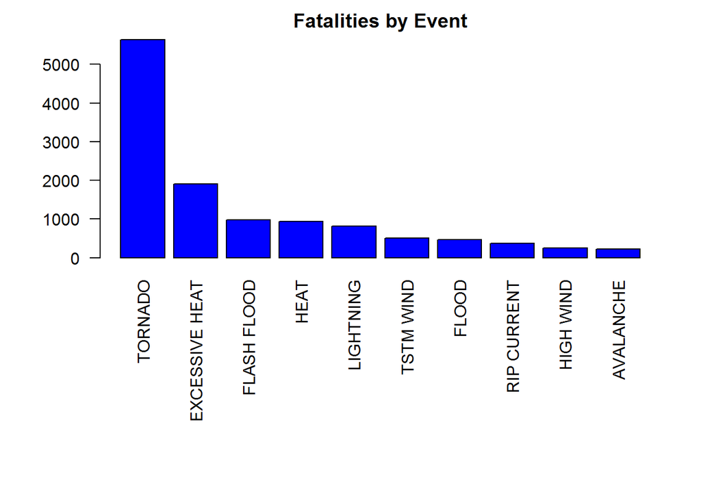

```r
fatal <- fatal[1:10,]
par(mar=c(12,5,2,2))
barplot(height = fatal$totalfatal, names.arg = fatal$EVTYPE, main = "Fatalities by Event", las = 2, col = "blue")
```

Tornados also caused the most injuries with 91346. Shown are the top 10 worst actors.

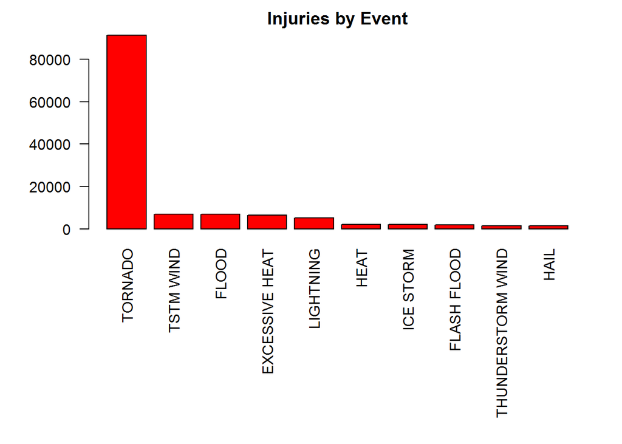

```r
injure <- injure[1:10,]
par(mar=c(12,5,2,2))
barplot(height = injure$totalinjure, names.arg = injure$EVTYPE, main = "Injuries by Event", las = 2, col = "red")
```

Floods caused the most damage with $144,657,709,870

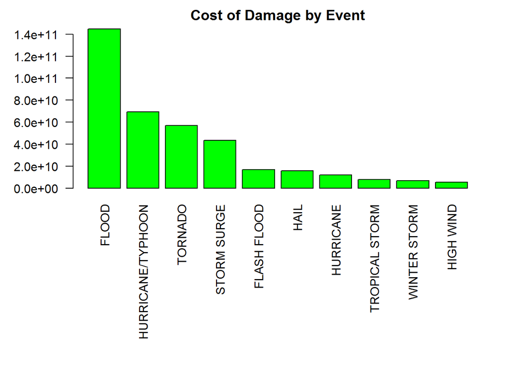

```r
damagetable <- damagetable[1:10,]
par(mar=c(12,5,2,2))
barplot(height = damagetable$totaldamage, names.arg = damagetable$EVTYPE, main = "Cost of Damage by Event",
          las = 2, col = "green")
```